# Problem Set 10

Ilayda Koca

2022-11-29

## Getting Set Up

If you haven’t already, create a folder for this course, and then a subfolder called `Topic10_Classification`, and two additional subfolders within `code` and `data`.

Open `RStudio` and create a new RMarkDown file (`.Rmd`) by going to `File -> New File -> R Markdown...`. Change the title to `"DS1000: Problem Set 10"` and the author to your full name. Save this file as `[LAST NAME]_ps10.Rmd` to your `code` folder.

If you haven’t already, download the `admit_data.rds` file from the course [github page](https://github.com/jbisbee1/DS1000-F2022/blob/master/Lectures/Topic10_Classification/data/admit_data.rds) and save it to your `data` folder.

Require `tidyverse`, `tidymodels`, and `modelr` and then load the `admit_data.rds` data to `ad`. Finally, `set.seed(123)` once at the very beginning, to ensure consistency in results throughout the problem set.

```r
require(tidyverse)
require(tidymodels)
require(modelr)
ad <-  readRDS('../data/admit_data.rds')
set.seed(123)
glimpse(ad)
```

```
## Rows: 2,150
## Columns: 14
## $ ID          <chr> "0001", "0002", "0003", "0004", "0005", "0006", "0007", "0…
## $ income      <dbl> 289720.59, 176763.29, 81204.02, 93320.52, 144991.22, 72720…
## $ sat         <dbl> 1107.403, 1387.607, 1000.000, 1134.883, 1202.686, 1053.033…
## $ gpa         <dbl> 3.597153, 4.000000, 3.072323, 3.682776, 3.970005, 3.474787…
## $ visit       <dbl> 0, 0, 0, 1, 1, 0, 0, 0, 1, 0, 1, 0, 0, 1, 1, 0, 0, 1, 0, 0…
## $ legacy      <dbl> 1, 0, 0, 0, 0, 0, 0, 0, 0, 0, 0, 0, 0, 0, 1, 0, 0, 1, 0, 1…
## $ registered  <dbl> 1, 1, 0, 1, 1, 0, 0, 1, 0, 0, 1, 1, 0, 0, 1, 0, 0, 1, 1, 1…
## $ sent_scores <dbl> 0, 0, 1, 0, 0, 1, 1, 0, 0, 0, 0, 0, 0, 0, 0, 0, 0, 0, 0, 0…
## $ distance    <dbl> 10.23279, 89.75984, 152.29961, 317.50274, 240.30712, 63.07…
## $ tuition     <dbl> 45000, 45000, 45000, 45000, 45000, 45000, 45000, 45000, 45…
## $ need_aid    <dbl> 0.000, 0.000, 8488.293, 3338.779, 0.000, 12093.802, 15156.…
## $ merit_aid   <dbl> 0.00, 35190.18, 0.00, 0.00, 30567.16, 0.00, 31633.66, 3219…
## $ net_price   <dbl> 45000.000, 9809.815, 36511.707, 41661.221, 14432.840, 3290…
## $ yield       <int> 1, 1, 1, 0, 1, 0, 1, 1, 0, 0, 0, 1, 0, 1, 1, 0, 0, 1, 1, 0…
```

## Question 1 [4 points]

Create a classification algorithm using linear regression that predicts attendance (`yield`) as a function of the following $X$ predictors:

- `distance`
- `income`
- `sat`
- `gpa`
- `visit`
- `registered`
- `legacy`
- `net_price`

Evaluate the model performance using `roc_auc` based on cross validation with 100 iterations, using an 80-20% split of the data. Then run a second algorithm that is identical to the first in every way, except that `income` is logged (`log_income = log(income)`). Compare the average AUC for the two models and discuss which is better.

**HINTS**:

- [Linear regression for classification](https://www.jamesbisbee.com/DS1000-F2022/Lectures/Topic10_Classification/code/Topic10_Classification_part1_slides.html#81)
- [Cross validation loop](https://www.jamesbisbee.com/DS1000-F2022/Lectures/Topic10_Classification/code/Topic10_Classification_part3_slides.html#23)

```r
# Create a classification algorithm using linear regression that predicts a attendance (`yield`)
mLM <- lm(yield ~ distance + income + sat + gpa + visit + registered + net_price + legacy,ad)

ad %>%
  mutate(pred_attend = ifelse(predict(mLM) > .5,1,0)) %>%
  group_by(yield) %>%
  mutate(total_attend = n()) %>%
  group_by(yield,pred_attend,total_attend) %>%
  summarise(nStudents=n(),.groups = 'drop') %>%
  mutate(prop = nStudents / total_attend) %>%
  ungroup() %>%
  mutate(accuracy = percent(sum((yield == pred_attend)*nStudents) / sum(nStudents)))
```

```
## # A tibble: 4 × 6
##   yield pred_attend total_attend nStudents   prop accuracy
##   <int>       <dbl>        <int>     <int>  <dbl> <chr>
## 1     0           0          684       387 0.566  80%
## 2     0           1          684       297 0.434  80%
## 3     1           0         1466       128 0.0873 80%
## 4     1           1         1466      1338 0.913  80%
```

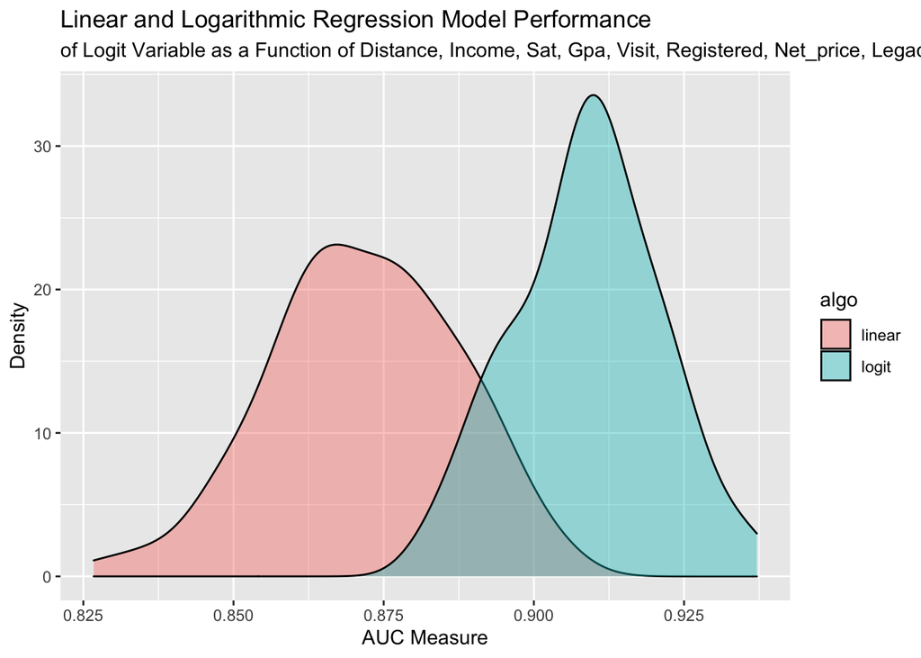

```r
# Income not logged (both linear and logarithmic)
bsRes <- NULL
for(i in 1:100) {
  # Cross validation prep
  inds <- sample(1:nrow(ad),size = round(nrow(ad)*.8),replace = F)
  train <- ad %>% slice(inds)
  test <- ad %>% slice(-inds)
  # Training models
  mLM <- lm(yield ~ distance + income + sat + gpa + visit + registered + net_price + legacy,train)
  mLG <- glm(yield ~ distance + income + sat + gpa + visit + registered + net_price + legacy,train,family = binomial(link = 'logit'))

  # Predicting models
  pred <- test %>%
    mutate(predLM = predict(mLM,newdata = test),
           predLG = predict(mLG,newdata = test, type = 'response'),
           truth = factor(yield,levels = c('1','0')))
  # Evaluating models
  resLG <- roc_auc(data = pred,truth = 'truth',estimate = 'predLG') %>%
    mutate(algo = 'logit')
  resLM <- roc_auc(data = pred,truth = 'truth',estimate = 'predLM') %>%
    mutate(algo = 'linear')
  bsRes <- resLG %>% bind_rows(resLM) %>% bind_rows(bsRes)
}

bsRes %>%
  ggplot(aes(x = .estimate,fill = algo)) +
  geom_density(alpha = .4) +
  labs(x = 'AUC Measure',
       y = 'Density',
       title = 'Linear and Logarithmic Regression Model Performance',
       subtitle = 'of Logit Variable as a Function of Distance, Income, Sat, Gpa, Visit, Registered, Net_price, Legacy')
```

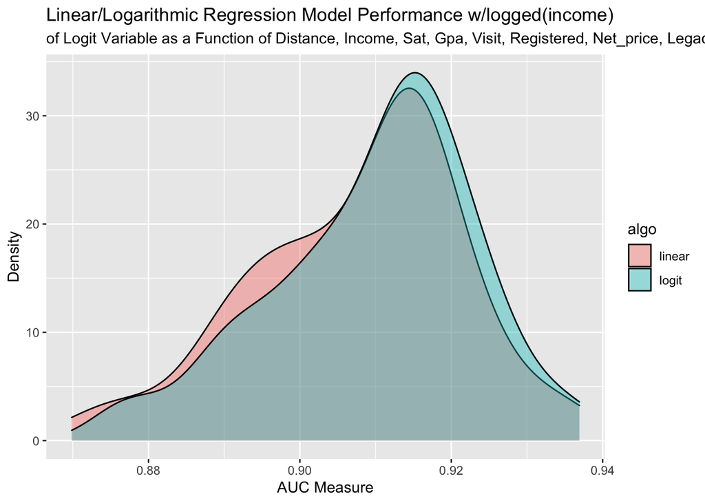

```r
# Logged income (both linear and logorithmic)
bsRes2 <- NULL
for(i in 1:100) {
  # Cross validation prep
  inds <- sample(1:nrow(ad),size = round(nrow(ad)*.8),replace = F)
  train <- ad %>% slice(inds)
  test <- ad %>% slice(-inds)
  # Training models
  mLM <- lm(yield ~ distance + log(income) + sat + gpa + visit + registered + net_price + legacy,train)
  mLG <- glm(yield ~ distance + log(income) + sat + gpa + visit + registered + net_price + legacy,train,family = binomial(link = 'logit'))

  # Predicting models
  pred <- test %>%
    mutate(predLM = predict(mLM,newdata = test),
           predLG = predict(mLG,newdata = test, type = 'response'),
           truth = factor(yield,levels = c('1','0')))
  # Evaluating models
  resLG <- roc_auc(data = pred,truth = 'truth',estimate = 'predLG') %>%
    mutate(algo = 'logit')
  resLM <- roc_auc(data = pred,truth = 'truth',estimate = 'predLM') %>%
    mutate(algo = 'linear')
  bsRes2 <- resLG %>% bind_rows(resLM) %>% bind_rows(bsRes2)
}

bsRes2 %>%
  ggplot(aes(x = .estimate,fill = algo)) +
  geom_density(alpha = .4) +
  labs(x = 'AUC Measure',
       y = 'Density',
       title = 'Linear/Logarithmic Regression Model Performance w/logged(income)',
       subtitle = 'of Logit Variable as a Function of Distance, Income, Sat, Gpa, Visit, Registered, Net_price, Legacy')
```

## Question 2 [4 points]

Re-do question 1 but use a logistic regression instead of a linear regression. Including the response to Question 1, you should end up with 100 AUC scores for each of the four algorithms by the end of this question:

- `lm` with raw `income`
- `lm` with `log_income`
- `glm` with raw `income`
- `glm` with `log_income`

Plot these AUC scores using `geom_boxplot()`, and discuss which of the four algorithms performs best.

**NB:** Make sure that `warning = F` in the first part of the beginning of the `r` code chunk!

**HINTS**:

- [Logit regression](https://www.jamesbisbee.com/DS1000-F2022/Lectures/Topic10_Classification/code/Topic10_Classification_part2_slides.html#35)

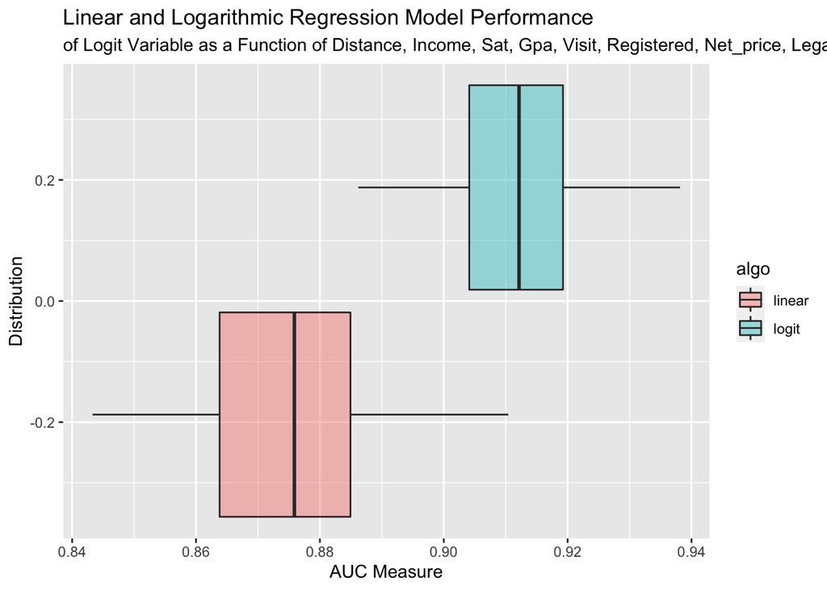

```r
# Income not logged (both linear and logarithmic)
bsRes <- NULL
for(i in 1:100) {
  # Cross validation prep
  inds <- sample(1:nrow(ad),size = round(nrow(ad)*.8),replace = F)
  train <- ad %>% slice(inds)
  test <- ad %>% slice(-inds)
  # Training models
  mLM <- lm(yield ~ distance + income + sat + gpa + visit + registered + net_price + legacy,train)
  mLG <- glm(yield ~ distance + income + sat + gpa + visit + registered + net_price + legacy,train,family = binomial(link = 'logit'))

  # Predicting models
  pred <- test %>%
    mutate(predLM = predict(mLM,newdata = test),
           predLG = predict(mLG,newdata = test, type = 'response'),
           truth = factor(yield,levels = c('1','0')))
  # Evaluating models
  resLG <- roc_auc(data = pred,truth = 'truth',estimate = 'predLG') %>%
    mutate(algo = 'logit')
  resLM <- roc_auc(data = pred,truth = 'truth',estimate = 'predLM') %>%
    mutate(algo = 'linear')
  bsRes <- resLG %>% bind_rows(resLM) %>% bind_rows(bsRes)
}

bsRes %>%
    ggplot(aes(x = .estimate,fill = algo)) +
    geom_boxplot(alpha = .4) +
    labs(x = 'AUC Measure',
       y = 'Distribution',
       title = 'Linear and Logarithmic Regression Model Performance',
       subtitle = 'of Logit Variable as a Function of Distance, Income, Sat, Gpa, Visit, Registered, Net_price, Legacy')
```

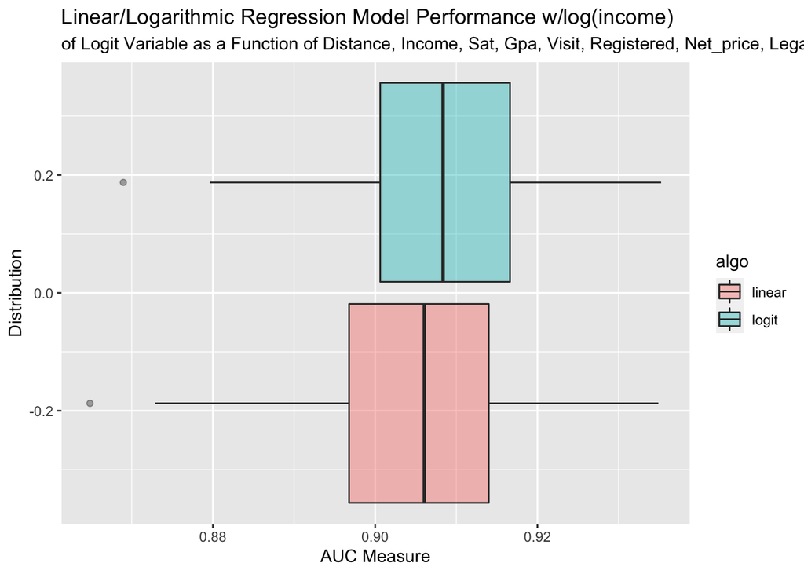

```r
# Logged income (both linear and logarithmic)
bsRes2 <- NULL
for(i in 1:100) {
  # Cross validation prep
  inds <- sample(1:nrow(ad),size = round(nrow(ad)*.8),replace = F)
  train <- ad %>% slice(inds)
  test <- ad %>% slice(-inds)
  # Training models
  mLM <- lm(yield ~ distance + log(income) + sat + gpa + visit + registered + net_price + legacy,train)
  mLG <- glm(yield ~ distance + log(income) + sat + gpa + visit + registered + net_price + legacy,train,family = binomial(link = 'logit'))

  # Predicting models
  pred <- test %>%
    mutate(predLM = predict(mLM,newdata = test),
           predLG = predict(mLG,newdata = test, type = 'response'),
           truth = factor(yield,levels = c('1','0')))
  # Evaluating models
  resLG <- roc_auc(data = pred,truth = 'truth',estimate = 'predLG') %>%
    mutate(algo = 'logit')
  resLM <- roc_auc(data = pred,truth = 'truth',estimate = 'predLM') %>%
    mutate(algo = 'linear')
  bsRes2 <- resLG %>% bind_rows(resLM) %>% bind_rows(bsRes2)
}
bsRes2 %>%
    ggplot(aes(x = .estimate,fill = algo)) +
    geom_boxplot(alpha = .4) +
    labs(x = 'AUC Measure',
       y = 'Distribution',
       title = 'Linear/Logarithmic Regression Model Performance w/log(income)',
       subtitle = 'of Logit Variable as a Function of Distance, Income, Sat, Gpa, Visit, Registered, Net_price, Legacy')
```